```python
from IPython.display import HTML

HTML('''<script>
  function code_toggle() {
    if (code_shown){
      $('div.input').hide('500');
      $('#toggleButton').val('Show Code')
    } else {
      $('div.input').show('500');
      $('#toggleButton').val('Hide Code')
    }
    code_shown = !code_shown
  }

  $( document ).ready(function(){
    code_shown=false;
    $('div.input').hide()
    $('div.output_subarea.output_text.output_stream.output_stderr').hide()
  });
</script>
<form action="javascript:code_toggle()"><input type="submit" id="toggleButton" value="Show Code"></form>''')
```

```python
import numpy as np
import plotly.plotly as py
from __future__ import division # division
import seaborn as sns # for visualiation
from scipy.stats import ttest_ind # t-tests
import statsmodels.formula.api as smf # linear modeling
import statsmodels.api as sm
from plotly.offline import plot # import plotly to graph distributions
import plotly.graph_objs as go
import matplotlib.pyplot as plt # plotting
import matplotlib
from sklearn import metrics
matplotlib.style.use('ggplot')
%matplotlib inline
import plotly
plotly.tools.set_credentials_file(username='stacyz', api_key='neQruuQsX8BVspubvIGV')

import pandas as pd
df = pd.read_csv('./YouthTobaccoSurveyData.csv')
```

```python
# generate a csv file of current smoker
df = df[np.isfinite(df['Data_Value'])]         # drop rows with no attribute "data_value"
smokingstat_df = df[df['MeasureDesc'] == "Smoking Status"]
current_smoker_df = smokingstat_df[smokingstat_df['Response'] == 'Current']
#current_smoker_df.to_csv('current_smoker.csv')
```

# Youth Tobacco Survey Analysis

In this resource, we provide supporting data, graphs, and evidence of important trends in youth tobacco usage to get attention from parents, schools, organizations, and the government.

The dataset we are using is the Youth Tobacco Survey (YTS) Data, which has been conducted by the Centers for Disease Control and Prevention (CDC) yearly since 1998. The dataset we accessed through Data.gov, where CDC has published and made it publicly accessible, includes only data for years between 1999 to 2015.

This resource provides information on:

- The overall trend of youth tobacco usage from 1999 to 2015.
- How the youth smoking users and trends differ in different states in the U.S.
- How the smoking status differs between males and females.
- How the percentage of current smokers who want to quit varies throughout the years

## Current Smoker Analysis

In this section we analyze current smoker trends for youth between 1999-2015. We focus on gender and education as two primary factors in our analysis. We also look at geographic location but decided that it isn't an important factor to continue with moving forward.

### Current Youth Smoker Percentage by Year and Gender

First we graph the mean overall percentage of current smokers. All states and education are combined and it is split between Male and Female self-identified gender. Here we can clearly see the overall decreasing trend over time for both males and females.

```python
# smoking status data by states
smokingstat_df = df[df['MeasureDesc'] == "Smoking Status"]
current_smoker_df = smokingstat_df[smokingstat_df['Response'] == 'Current']
# current_smoker_df
```

```python
# Mean Data_Value by sex & year
mean = current_smoker_df[['Gender', 'Data_Value', 'YEAR']].groupby(['Gender','YEAR']).agg('mean').reset_index()
female = current_smoker_df[['Gender', 'Data_Value', 'YEAR']].groupby(['Gender']).get_group('Female')
female_current_smoker_mean_by_year = female.groupby('YEAR').agg('mean').reset_index()
male = current_smoker_df[['Gender', 'Data_Value', 'YEAR']].groupby(['Gender']).get_group('Male')
male_current_smoker_mean_by_year = male.groupby('YEAR').agg('mean').reset_index()
```

```python
trace_current_male_smoker = go.Scatter(
    x = male_current_smoker_mean_by_year.YEAR,
    y = male_current_smoker_mean_by_year.Data_Value,
    name = 'male',
)

trace_current_female_smoker = go.Scatter(
    x = female_current_smoker_mean_by_year.YEAR,
    y = female_current_smoker_mean_by_year.Data_Value,
    name = 'female',
    line = dict(
        color = ('rgb(205, 12, 24)'),)
)

# Edit the layout
layout = dict(title = 'Percentage of current youth tobacco user (by gender)',
              xaxis = dict(title = 'Year'),
              yaxis = dict(title = 'Percentage'),
              )
```

```python
data = [trace_current_male_smoker, trace_current_female_smoker]

fig = dict(data=data, layout=layout)
py.iplot(fig, filename = 'Percentage of current youth tobacco user (by gender)')
```

[interactive chart not shown]

```python
# Mean Data_Value by sex & year
mean_1 = current_smoker_df[['Education', 'Data_Value', 'YEAR']].groupby(['Education','YEAR']).agg('mean').reset_index()
middle_school = current_smoker_df[['Education', 'Data_Value', 'YEAR']].groupby(['Education']).get_group('Middle School')
middle_school_current_smoker_mean_by_year = middle_school.groupby('YEAR').agg('mean').reset_index()
high_school = current_smoker_df[['Education', 'Data_Value', 'YEAR']].groupby(['Education']).get_group('High School')
high_school_current_smoker_mean_by_year = high_school.groupby('YEAR').agg('mean').reset_index()
```

```python
trace_current_middle_school_smoker = go.Scatter(
    x = middle_school_current_smoker_mean_by_year.YEAR,
    y = middle_school_current_smoker_mean_by_year.Data_Value,
    name = 'middle school',
)

trace_current_high_school_smoker = go.Scatter(
    x = high_school_current_smoker_mean_by_year.YEAR,
    y = high_school_current_smoker_mean_by_year.Data_Value,
    name = 'high school',
    line = dict(
        color = ('rgb(205, 12, 24)'),)
)

# Edit the layout
layout = dict(title = 'Percentage of current youth tobacco user (by education)',
              xaxis = dict(title = 'Year'),
              yaxis = dict(title = 'Percentage'),
              )
```

```python
data = [trace_current_middle_school_smoker, trace_current_high_school_smoker]

fig = dict(data=data, layout=layout)
py.iplot(fig, filename = 'Percentage of current youth tobacco user (by education)')
```

[interactive chart not shown]

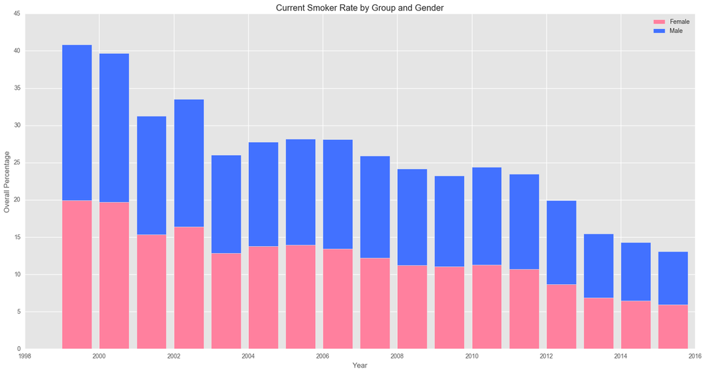

```python
plt.figure(figsize=(20,10))

plt.bar(female_current_smoker_mean_by_year.YEAR, female_current_smoker_mean_by_year.Data_Value,
        color=(1.0,0.5,0.62), label='Female')
plt.bar(male_current_smoker_mean_by_year.YEAR, male_current_smoker_mean_by_year.Data_Value,
        color=(0.2588,0.4433,1.0), label='Male',bottom=female_current_smoker_mean_by_year.Data_Value)
plt.xlabel('Year')
plt.ylabel('Overall Percentage')
plt.title('Current Smoker Rate by Group and Gender')

plt.legend(loc='upper right')
plt.show()
```

```python
# current high school smoker (overall) by states
c_hs_smoker = current_smoker_df[(current_smoker_df['Education'] == 'High School') & (current_smoker_df['Gender'] == 'Overall')]
#c_hs_smoker
```

### Current Youth Smoker Percentage by Year and State

We then wanted to look at how the percentage varied by state to see whether there were any states that either had any unusual trends or significantly affected the overall percentage nationwide. Here, all other factors such as gender and education are not considered and only the overall percentages are shown. (A few states have not been included due to insufficient data, including Alaska, Idaho, Maine, Montana, Nevada, New Mexico, Oregon, Virginia, Washington, and Wyoming).

```python
# current high school smoker grouped by states
c_hs_smoker = c_hs_smoker.sort_values(by = ['LocationAbbr', 'YEAR'])
c_hs_smoker_short = c_hs_smoker[['LocationAbbr', 'YEAR', 'Data_Value']]
```

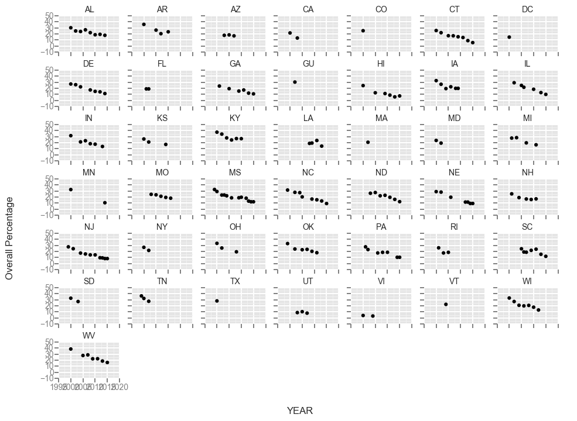

```python
from ggplot import *
p = ggplot(c_hs_smoker_short, aes(x='YEAR', y='Data_Value'))
p + geom_point() + \
    facet_wrap("LocationAbbr") + ylab("Overall Percentage")
```

```python
# by gender
#current_smoker_df = smokingstat_df[(smokingstat_df['Gender'] == 'Female') & (s)]
current_smoker_by_gender = current_smoker_df[current_smoker_df['Gender'].isin(['Female', 'Male'])]
```

### Current Youth Smoker Percentage by Gender and Education

Self-described Gender (Male or Female) and Education (Middle School or High School) were the primary independent variables we analyzed from our YTS dataset. Here we first look at the overall distributions of data for both of these variables, and then we combine them.

#### Current Youth Smoker Percentage by Gender

First we plotted the distribution of current smokers by gender between 1999-2015. Areas with greater density of data points indicate more points where there was that percentage of male current smokers. We noted that the female distribution is mostly bottom-heavy with a greater concentration of points near the 0%-10% range while the male distribution was more spread out between 0%-30%.

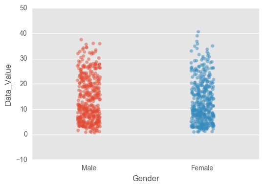

```python
# Show current smoking rate distributions between male and female youth in a stripplot
sns.stripplot(x='Gender', y='Data_Value', data=current_smoker_by_gender, jitter=True, edgecolor='none', alpha=.5)
sns.despine()
```

```python
# by education
current_smoker_by_education = current_smoker_df[current_smoker_df['Gender'] == 'Overall']
```

#### Current Youth Smoker Percentage by Education

Then we plotted the distribution of current smokers by education, there is a clear distinction between the distributions for Middle School and High School, with current smokers in middle school mostly between the 0%-10% range while current smokers in high school are concentrated around the 15%-30% range. Education level is clearly a factor that makes a difference in current youth smokers. Particularly, there is a greater percentage of high school smokers. This is likely because it is easier for them to get access to cigarettes and an increased individual interest in smoking.

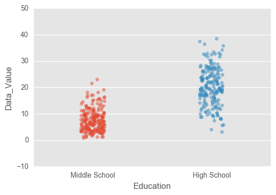

```python
sns.stripplot(x='Education', y='Data_Value', data=current_smoker_by_education,
              jitter=True, edgecolor='none', alpha=.5)
sns.despine()
```

#### Current Youth Smoker Percentage by Gender between Education

We graphed the percentages of current smokers by gender for the two educations (Middle School and High School) next to each other to direction compare the distributions. Here we can see that gender does not make much of a difference on the percentage of current smokers as both males and females are relatively within the same distributions for both Middle School and High School. In other words, for Middle School, both Males and Females are mostly contained within the 0%-20% range, while for High School, both Males and Females are mostly contained within the 10%-30% range.

The difference between the two ranges for the two education levels, however indicates the effect education has on current smokers, namely that the percentage of current smokers increases between middle school and high school.

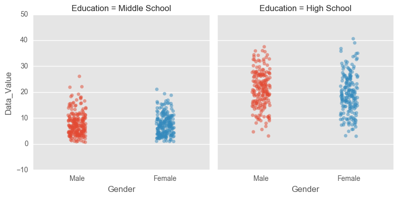

```python
# Create different stripplots of salary (by gender) for each rank
sns.factorplot(x="Gender", y="Data_Value",
               col="Education", data=current_smoker_by_gender, kind="strip", jitter=True, edgecolor='none', alpha=.5);
```

## Cessation Status Analysis

In this section we analyze cessation statuses for youth between 1999-2015. We only focus on education as our primary factor in our analysis because we found that gender does not have much of a distinct effect in the previous section.

### Tobacco Users Who Want to Quit

Here we graph the average percentage of current tobacco-using youth who want to quit by education (middle and high school) per year. We can see that there is clearly an overall decreasing trend in those who want to quit. It is interesting to note two instances where there is a greater precentage of middle schoolers who want to quit than there are high schoolers in 2007 and 2010.

```python
# current smokers who want to quit and attempt to quit
df_quit = df[df['MeasureDesc'] == 'Percent of Current Smokers Who Want to Quit']
df_attempt_quit = df[df['MeasureDesc'] == 'Quit Attempt in Past Year Among Current Cigarette Smokers']
```

```python
# users want to quit (middle school)
df_overall_middle = df_quit[(df_quit['Gender'] == 'Overall') & (df_quit['Education'] == 'Middle School')]
a = df_overall_middle.groupby('YEAR').mean().reset_index()
```

```python
# users want to quit (high school)
df_overall_high = df_quit[(df_quit['Gender'] == 'Overall') & (df_quit['Education'] == 'High School')]
c = df_overall_high.groupby('YEAR').mean().reset_index()
```

```python
# Create a trace

trace_middle_school = go.Scatter(
    x = a.YEAR,
    y = a.Data_Value,
    name = 'middle school',
)

trace_high_school = go.Scatter(
    x = c.YEAR,
    y = c.Data_Value,
    name = 'high school',
    line = dict(
        color = ('rgb(205, 12, 24)'),)
)

# Edit the layout
layout = dict(title = 'Average youth tobacco users who want to quit',
              xaxis = dict(title = 'Year'),
              yaxis = dict(title = 'Percentage'),
              )
```

```python
data = [trace_middle_school, trace_high_school]

fig = dict(data=data, layout=layout)
py.iplot(fig, filename = 'Average youth tobacco users who want to quit')
```

[interactive chart not shown]

### Tobacco Users Who Attempt to Quit

Then we graph the average percentage of total youth tobacco users who actually attempt to quit by education level for each year. There is an unusual spike in percentage of quit attempts in 2012 for both middle and high schoolers, although the middle school tobacco users had a much greater sudden increase.

It is notable to compare that in 2012, there is also a noticeable peak in average tobacco users who want to quit. It is interesting then, that the average percentage of users who attempt to quit continues to stay peaked while the percentage of users who want to quit decreases. This could potentially be explained by a past attempt to quit, which led to decreased current interest in quitting.

```python
df_overall_middle_a = df_attempt_quit[(df_attempt_quit['Gender'] == 'Overall') & (df_attempt_quit['Education'] == 'Middle School')]
b = df_overall_middle_a.groupby('YEAR').mean().reset_index()
```

```python
df_overall_high_a = df_attempt_quit[(df_attempt_quit['Gender'] == 'Overall') & (df_attempt_quit['Education'] == 'High School')]
d = df_overall_high_a.groupby('YEAR').mean().reset_index()
```

```python
trace_middle_school_attempt = go.Scatter(
    x = b.YEAR,
    y = b.Data_Value,
    name = 'middle school',
)

trace_high_school_attempt = go.Scatter(
    x = d.YEAR,
    y = d.Data_Value,
    name = 'high school',
    line = dict(
        color = ('rgb(205, 12, 24)'),)
)

# Edit the layout
layout = dict(title = 'Average youth tobacco users who attempt to quit',
              xaxis = dict(title = 'Year'),
              yaxis = dict(title = 'Percentage'),
              )
```

```python
data_attempt = [trace_middle_school_attempt, trace_high_school_attempt]

fig = dict(data=data_attempt, layout=layout)
py.iplot(fig, filename = 'Average youth tobacco users who attempt to quit')
```

[interactive chart not shown]

### Linear model Fitting Current Smokers Throughout the Past Decade

We fit a linear model for current smokers through the past decade. The adjusted R-squared for current smokers is 0.759, indicating good fit of the model to the data. Our P-values are also significant between current smoking rate and males and between current smoking rate and middle school. The coefficient for males is positive while it is negative for middle school education. This indicates that there is a significant positive relationship between males and currently smoking status, and a significant negative relationship between middle schoolers and current smoking.

```python
current_smoker_df['Data_Value'] = current_smoker_df['Data_Value'] / 100
```

```python
lm = smf.ols(formula='Data_Value ~ YEAR + Gender + Education', data=current_smoker_df).fit()
lm.summary()
```

OLS Regression Results

| Dep. Variable: | Data_Value | R-squared: | 0.760 |
| --- | --- | --- | --- |
| Model: | OLS | Adj. R-squared: | 0.759 |
| Method: | Least Squares | F-statistic: | 988.7 |
| Date: | Tue, 07 Mar 2017 | Prob (F-statistic): | 0.00 |
| Time: | 14:21:55 | Log-Likelihood: | 2198.1 |
| No. Observations: | 1257 | AIC: | -4386. |
| Df Residuals: | 1252 | BIC: | -4360. |
| Df Model: | 4 |  |  |
| Covariance Type: | nonrobust |  |  |

|  | coef | std err | t | P>\|t\| | [95.0% Conf. Int.] |
| --- | --- | --- | --- | --- | --- |
| Intercept | 16.6829 | 0.491 | 33.967 | 0.000 | 15.719 17.646 |
| Gender[T.Male] | 0.0104 | 0.003 | 3.566 | 0.000 | 0.005 0.016 |
| Gender[T.Overall] | 0.0057 | 0.003 | 1.950 | 0.051 | -3.34e-05 0.011 |
| Education[T.Middle School] | -0.1299 | 0.002 | -54.428 | 0.000 | -0.135 -0.125 |
| YEAR | -0.0082 | 0.000 | -33.567 | 0.000 | -0.009 -0.008 |

| Omnibus: | 129.754 | Durbin-Watson: | 1.046 |
| --- | --- | --- | --- |
| Prob(Omnibus): | 0.000 | Jarque-Bera (JB): | 439.267 |
| Skew: | -0.481 | Prob(JB): | 4.12e-96 |
| Kurtosis: | 5.732 | Cond. No. | 8.28e+05 |

```python
# Create predictions using this model
current_smoker_df['mult_preds'] = lm.predict()
```

Then we test the model fit with the actual values by plotting the predicted percentage on the x-axis with the actual recorded percentage on the y-axis. We also plotted a red line through the diagonal to indicate perfect fit. Therefore, the closer the cluster is around the red line, the better our model has predicted the values. We can see that most of the predictions are relatively close to their actual values, but there are a few outliers.

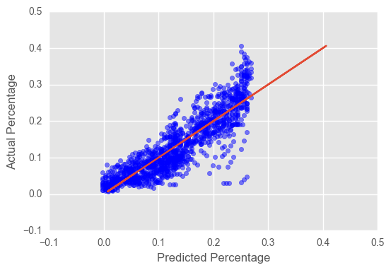

```python
# Compare predictions to observations
plt.scatter(current_smoker_df.mult_preds, current_smoker_df.Data_Value, color = 'blue', alpha = 0.5)
plt.plot(current_smoker_df.Data_Value, current_smoker_df.Data_Value)
plt.xlabel("Predicted Percentage")
plt.ylabel("Actual Percentage")
plt.show()
```

```python
# Visually compare predictions over year
#plt.scatter(current_smoker_df.YEAR, current_smoker_df.Data_Value, color = 'blue')
#plt.scatter(current_smoker_df.YEAR, current_smoker_df.mult_preds, color='red')
#plt.show()
```

```python
df_quit['Data_Value'] = df_quit['Data_Value'] / 100
```

```python
lm_quit = smf.ols(formula='Data_Value ~ YEAR + Gender + Education', data=df_quit).fit()
lm_quit.summary()
```

OLS Regression Results

| Dep. Variable: | Data_Value | R-squared: | 0.280 |
| --- | --- | --- | --- |
| Model: | OLS | Adj. R-squared: | 0.276 |
| Method: | Least Squares | F-statistic: | 91.66 |
| Date: | Tue, 07 Mar 2017 | Prob (F-statistic): | 7.07e-66 |
| Time: | 14:23:10 | Log-Likelihood: | 1232.9 |
| No. Observations: | 950 | AIC: | -2456. |
| Df Residuals: | 945 | BIC: | -2432. |
| Df Model: | 4 |  |  |
| Covariance Type: | nonrobust |  |  |

|  | coef | std err | t | P>\|t\| | [95.0% Conf. Int.] |
| --- | --- | --- | --- | --- | --- |
| Intercept | 17.1482 | 0.949 | 18.079 | 0.000 | 15.287 19.010 |
| Gender[T.Male] | -0.0386 | 0.006 | -6.988 | 0.000 | -0.049 -0.028 |
| Gender[T.Overall] | -0.0173 | 0.005 | -3.297 | 0.001 | -0.028 -0.007 |
| Education[T.Middle School] | -0.0290 | 0.005 | -6.435 | 0.000 | -0.038 -0.020 |
| YEAR | -0.0083 | 0.000 | -17.510 | 0.000 | -0.009 -0.007 |

| Omnibus: | 18.009 | Durbin-Watson: | 1.505 |
| --- | --- | --- | --- |
| Prob(Omnibus): | 0.000 | Jarque-Bera (JB): | 29.953 |
| Skew: | 0.124 | Prob(JB): | 3.13e-07 |
| Kurtosis: | 3.834 | Cond. No. | 8.85e+05 |

```python
# Create predictions using this model
df_quit['mult_preds'] = lm_quit.predict()
```

We then graphed the model predictions against the actual data. From this we can see a downward trend and then expect that it will continue to decrease in the future.

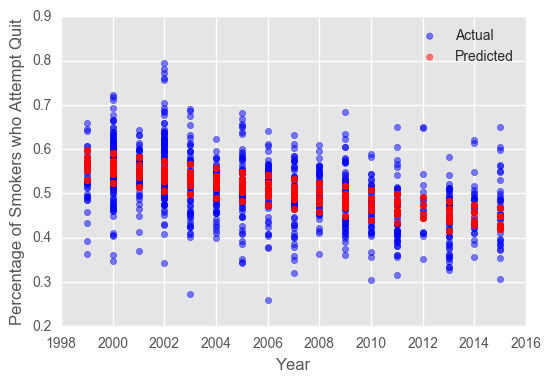

```python
# Compare predictions to observations
plt.scatter(df_quit.YEAR, df_quit.Data_Value, color = 'blue', alpha = 0.5, label='Actual')
plt.scatter(df_quit.YEAR, df_quit.mult_preds, color = 'red', alpha = 0.5, label='Predicted')
#plt.ylim((0, 0.1))
plt.xlabel("Year")
plt.ylabel("Percentage of Smokers who Attempt Quit")
plt.legend(loc='upper right')
plt.show()
```

## Final Analysis

With the trends we've noted among those who want to quit and those who have attempted to quit, our analysis suggests that it is important to continue educating youth about tobacco and regulating it externally to further disinterest them in tobacco usage.